# MaTh - Material and Methods

Joshua Johnson

```r
library(tidyverse)
library(dplyr)
library(ggplot2)
library(cowplot)
library(reshape2)
library(rstatix)
library(ggpubr)
library(nlme)
library(lme4)
library(kableExtra)
```

| type | id | n | avg.qty | sd.qty | dna_conc | unit | qty_undil | qty_ul | qty_ng |
| --- | --- | --- | --- | --- | --- | --- | --- | --- | --- |
| rhizo | 198 | 3 | 230588.11457 | 12685.95338 | 35.82 | DNA[ng_ul] | 92235245.83 | 11529405.728 | 321870.62335 |
| rhizo | 201 | 3 | 228907.02083 | 6576.32117 | 38.13 | DNA[ng_ul] | 91562808.33 | 11445351.042 | 300166.56286 |
| rhizo | 206 | 3 | 332462.67710 | 6922.59699 | 47.48 | DNA[ng_ul] | 132985070.84 | 16623133.855 | 350108.12668 |
| rhizo | 212 | 3 | 210821.31770 | 25403.47329 | 35.07 | DNA[ng_ul] | 84328527.08 | 10541065.885 | 300572.16667 |
| rhizo | 216 | 3 | 488171.95837 | 25381.55053 | 52.80 | DNA[ng_ul] | 195268783.35 | 24408597.918 | 462284.05148 |
| rhizo | 224 | 3 | 252673.63543 | 30487.99295 | 38.58 | DNA[ng_ul] | 101069454.17 | 12633681.772 | 327467.12731 |
| rhizo | 226 | 3 | 353033.38543 | 31415.49520 | 50.33 | DNA[ng_ul] | 141213354.17 | 17651669.272 | 350718.64239 |
| rhizo | 232 | 3 | 583032.95833 | 12524.11670 | 60.16 | DNA[ng_ul] | 233213183.33 | 29151647.917 | 484568.61564 |
| rhizo | 234 | 3 | 522108.81250 | 92493.41227 | 61.10 | DNA[ng_ul] | 208843525.00 | 26105440.625 | 427257.62070 |
| rhizo | 237 | 3 | 287492.71880 | 3463.10904 | 43.06 | DNA[ng_ul] | 114997087.52 | 14374635.940 | 333828.05248 |

[output cut: 70 more lines]

| type | id | qty_ng | unit | treatment | fert | fung | block | row | time | subject |
| --- | --- | --- | --- | --- | --- | --- | --- | --- | --- | --- |
| rhizo | 198 | 321870.62335 | GeneCopies/ngDNA | H00 | no | no | b | 1 | t2 | 1 |
| rhizo | 201 | 300166.56286 | GeneCopies/ngDNA | H00 | no | no | c | 1 | t2 | 2 |
| rhizo | 206 | 350108.12668 | GeneCopies/ngDNA | H01 | yes | no | b | 1 | t2 | 6 |
| rhizo | 212 | 300572.16667 | GeneCopies/ngDNA | HP0 | no | yes | b | 1 | t2 | 11 |
| rhizo | 216 | 462284.05148 | GeneCopies/ngDNA | HP1 | yes | yes | b | 1 | t2 | 16 |
| rhizo | 224 | 327467.12731 | GeneCopies/ngDNA | HP0 | no | yes | c | 2 | t2 | 12 |
| rhizo | 226 | 350718.64239 | GeneCopies/ngDNA | HP0 | no | yes | e | 2 | t2 | 13 |
| rhizo | 232 | 484568.61564 | GeneCopies/ngDNA | H00 | no | no | d | 2 | t2 | 3 |
| rhizo | 234 | 427257.62070 | GeneCopies/ngDNA | HP1 | yes | yes | c | 2 | t2 | 17 |
| rhizo | 237 | 333828.05248 | GeneCopies/ngDNA | H01 | yes | no | c | 2 | t2 | 7 |
| rhizo | 247 | 320024.06902 | GeneCopies/ngDNA | H01 | yes | no | d | 3 | t2 | 8 |
| rhizo | 251 | 359682.24711 | GeneCopies/ngDNA | H01 | yes | no | f | 3 | t2 | 9 |
| rhizo | 253 | 319869.04163 | GeneCopies/ngDNA | HP1 | yes | yes | f | 3 | t2 | 18 |
| rhizo | 259 | 404321.64935 | GeneCopies/ngDNA | H00 | no | no | e | 3 | t2 | 4 |
| rhizo | 263 | 333653.28311 | GeneCopies/ngDNA | HP0 | no | yes | f | 3 | t2 | 14 |
| rhizo | 269 | 410088.35585 | GeneCopies/ngDNA | HP1 | yes | yes | e | 4 | t2 | 19 |
| rhizo | 276 | 412485.87717 | GeneCopies/ngDNA | HP1 | yes | yes | d | 4 | t2 | 20 |
| rhizo | 279 | 357515.09020 | GeneCopies/ngDNA | HP0 | no | yes | d | 4 | t2 | 15 |
| rhizo | 281 | 315001.45124 | GeneCopies/ngDNA | H01 | yes | no | e | 4 | t2 | 10 |
| rhizo | 286 | 345117.60719 | GeneCopies/ngDNA | H00 | no | no | f | 4 | t2 | 5 |
| rhizo | 294 | 225341.44020 | GeneCopies/ngDNA | H00 | no | no | b | 1 | t3 | 1 |
| rhizo | 297 | 232715.25359 | GeneCopies/ngDNA | H00 | no | no | c | 1 | t3 | 2 |
| rhizo | 302 | 400464.78075 | GeneCopies/ngDNA | H01 | yes | no | b | 1 | t3 | 6 |
| rhizo | 308 | 257454.43740 | GeneCopies/ngDNA | HP0 | no | yes | b | 1 | t3 | 11 |
| rhizo | 312 | 326452.08739 | GeneCopies/ngDNA | HP1 | yes | yes | b | 1 | t3 | 16 |
| rhizo | 320 | 270265.51515 | GeneCopies/ngDNA | HP0 | no | yes | c | 2 | t3 | 12 |
| rhizo | 322 | 244425.11425 | GeneCopies/ngDNA | HP0 | no | yes | d | 2 | t3 | 13 |
| rhizo | 328 | 227718.32266 | GeneCopies/ngDNA | H00 | no | no | d | 2 | t3 | 3 |
| rhizo | 330 | 312167.08613 | GeneCopies/ngDNA | HP1 | yes | yes | c | 2 | t3 | 17 |
| rhizo | 333 | 268555.73873 | GeneCopies/ngDNA | H01 | yes | no | c | 2 | t3 | 7 |
| rhizo | 343 | 259740.78780 | GeneCopies/ngDNA | H01 | yes | no | d | 3 | t3 | 8 |
| rhizo | 347 | 327009.74162 | GeneCopies/ngDNA | H01 | yes | no | e | 3 | t3 | 9 |
| rhizo | 349 | 296872.94029 | GeneCopies/ngDNA | HP1 | yes | yes | d | 3 | t3 | 18 |
| rhizo | 355 | 290010.04074 | GeneCopies/ngDNA | H00 | no | no | e | 3 | t3 | 4 |
| rhizo | 359 | 243743.34729 | GeneCopies/ngDNA | HP0 | no | yes | e | 3 | t3 | 14 |
| rhizo | 365 | 263310.95412 | GeneCopies/ngDNA | HP1 | yes | yes | e | 4 | t3 | 19 |
| rhizo | 372 | 288440.89479 | GeneCopies/ngDNA | HP1 | yes | yes | f | 4 | t3 | 20 |
| rhizo | 375 | 281575.70569 | GeneCopies/ngDNA | HP0 | no | yes | f | 4 | t3 | 15 |
| rhizo | 377 | 244924.30089 | GeneCopies/ngDNA | H01 | yes | no | f | 4 | t3 | 10 |
| rhizo | 382 | 224447.30612 | GeneCopies/ngDNA | H00 | no | no | f | 4 | t3 | 5 |
| soil | 198 | 411193.09734 | GeneCopies/ngDNA | H00 | no | no | b | 1 | t2 | 1 |
| soil | 201 | 418.79029 | GeneCopies/ngDNA | H00 | no | no | c | 1 | t2 | 2 |
| soil | 206 | 428078.96706 | GeneCopies/ngDNA | H01 | yes | no | b | 1 | t2 | 6 |
| soil | 212 | 142871.54804 | GeneCopies/ngDNA | HP0 | no | yes | b | 1 | t2 | 11 |
| soil | 216 | 435527.69468 | GeneCopies/ngDNA | HP1 | yes | yes | b | 1 | t2 | 16 |
| soil | 224 | 413278.78890 | GeneCopies/ngDNA | HP0 | no | yes | c | 2 | t2 | 12 |
| soil | 226 | 934283.47497 | GeneCopies/ngDNA | HP0 | no | yes | e | 2 | t2 | 13 |
| soil | 232 | 624.73535 | GeneCopies/ngDNA | H00 | no | no | d | 2 | t2 | 3 |
| soil | 234 | 392734.17757 | GeneCopies/ngDNA | HP1 | yes | yes | c | 2 | t2 | 17 |
| soil | 237 | 451179.80468 | GeneCopies/ngDNA | H01 | yes | no | c | 2 | t2 | 7 |
| soil | 247 | 420747.05654 | GeneCopies/ngDNA | H01 | yes | no | d | 3 | t2 | 8 |
| soil | 251 | 406455.69955 | GeneCopies/ngDNA | H01 | yes | no | f | 3 | t2 | 9 |
| soil | 253 | 373044.70616 | GeneCopies/ngDNA | HP1 | yes | yes | f | 3 | t2 | 18 |
| soil | 259 | 412127.52575 | GeneCopies/ngDNA | H00 | no | no | e | 3 | t2 | 4 |
| soil | 263 | 780219.29006 | GeneCopies/ngDNA | HP0 | no | yes | f | 3 | t2 | 14 |
| soil | 269 | 440260.04122 | GeneCopies/ngDNA | HP1 | yes | yes | e | 4 | t2 | 19 |
| soil | 276 | 449011.51602 | GeneCopies/ngDNA | HP1 | yes | yes | d | 4 | t2 | 20 |
| soil | 279 | 172835.23435 | GeneCopies/ngDNA | HP0 | no | yes | d | 4 | t2 | 15 |
| soil | 281 | 422020.93403 | GeneCopies/ngDNA | H01 | yes | no | e | 4 | t2 | 10 |
| soil | 286 | 751.12714 | GeneCopies/ngDNA | H00 | no | no | f | 4 | t2 | 5 |
| soil | 294 | 226141.20276 | GeneCopies/ngDNA | H00 | no | no | b | 1 | t3 | 1 |
| soil | 297 | 193850.79154 | GeneCopies/ngDNA | H00 | no | no | c | 1 | t3 | 2 |
| soil | 302 | 166194.89102 | GeneCopies/ngDNA | H01 | yes | no | b | 1 | t3 | 6 |
| soil | 308 | 194456.92923 | GeneCopies/ngDNA | HP0 | no | yes | b | 1 | t3 | 11 |
| soil | 312 | 182801.12753 | GeneCopies/ngDNA | HP1 | yes | yes | b | 1 | t3 | 16 |
| soil | 320 | 210373.69944 | GeneCopies/ngDNA | HP0 | no | yes | c | 2 | t3 | 12 |
| soil | 322 | 200180.93782 | GeneCopies/ngDNA | HP0 | no | yes | d | 2 | t3 | 13 |
| soil | 328 | 234292.21689 | GeneCopies/ngDNA | H00 | no | no | d | 2 | t3 | 3 |
| soil | 330 | 166610.02824 | GeneCopies/ngDNA | HP1 | yes | yes | c | 2 | t3 | 17 |
| soil | 333 | 171520.99017 | GeneCopies/ngDNA | H01 | yes | no | c | 2 | t3 | 7 |
| soil | 343 | 219416.83916 | GeneCopies/ngDNA | H01 | yes | no | d | 3 | t3 | 8 |
| soil | 347 | 149368.62334 | GeneCopies/ngDNA | H01 | yes | no | e | 3 | t3 | 9 |
| soil | 349 | 168626.61856 | GeneCopies/ngDNA | HP1 | yes | yes | d | 3 | t3 | 18 |
| soil | 355 | 214247.11881 | GeneCopies/ngDNA | H00 | no | no | e | 3 | t3 | 4 |
| soil | 359 | 167569.09678 | GeneCopies/ngDNA | HP0 | no | yes | e | 3 | t3 | 14 |
| soil | 365 | 248031.82250 | GeneCopies/ngDNA | HP1 | yes | yes | e | 4 | t3 | 19 |
| soil | 372 | 84677.62819 | GeneCopies/ngDNA | HP1 | yes | yes | f | 4 | t3 | 20 |
| soil | 375 | 214504.38592 | GeneCopies/ngDNA | HP0 | no | yes | f | 4 | t3 | 15 |
| soil | 377 | 179827.32643 | GeneCopies/ngDNA | H01 | yes | no | f | 4 | t3 | 10 |
| soil | 382 | 99.02057 | GeneCopies/ngDNA | H00 | no | no | f | 4 | t3 | 5 |

The data preparation is finished for the 16s rRNA gene copy data. We have worked with the raw quantity values used qPCR machine (standardized on the individual runs standard curve), did summary statistics (averaging the technical replicates) and calculated gene copy number per nanogram DNA.

Now we move on to the statistical modelling and checking for significance.

# Statistical modelling and sig. testing

## Rhizo

### Checking data balance

| fert | fung | time | variable | n | mean | sd |
| --- | --- | --- | --- | --- | --- | --- |
| no | no | t2 | qty_ng | 5 | 371209.0 | 74345.33 |
| no | no | t3 | qty_ng | 5 | 240046.5 | 28114.32 |
| no | yes | t2 | qty_ng | 5 | 333985.3 | 22319.78 |
| no | yes | t3 | qty_ng | 5 | 259492.8 | 16454.04 |
| yes | no | t2 | qty_ng | 5 | 335728.8 | 19107.64 |
| yes | no | t3 | qty_ng | 5 | 300139.1 | 64158.94 |
| yes | yes | t2 | qty_ng | 5 | 406397.0 | 52669.53 |
| yes | yes | t3 | qty_ng | 5 | 297448.8 | 24003.57 |

We have a balanced dataset (n is the same for each group). Moving on to a boxplot to visually inspect groups and look for outliers.

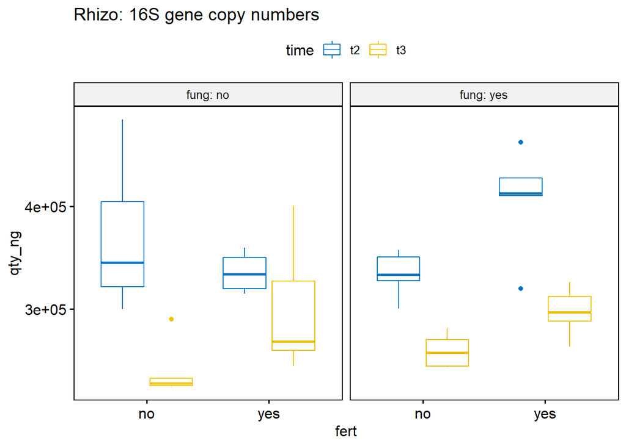

We have one outlier in [fert:no|fung:no|time:t3] and two outliers in [fert:yes|fung:yes|time:t2]. Identifying the outliers:

| fert | fung | time | id | qty_ng | block | row | subject | is.outlier | is.extreme |
| --- | --- | --- | --- | --- | --- | --- | --- | --- | --- |
| no | no | t3 | 355 | 290010.0 | e | 3 | 4 | TRUE | TRUE |
| yes | yes | t2 | 216 | 462284.1 | b | 1 | 16 | TRUE | FALSE |
| yes | yes | t2 | 253 | 319869.0 | f | 3 | 18 | TRUE | TRUE |

Replicate 216, 355 and 253 are outliers. The two last ones are extreme outliers. Consult the ‘index’ file to see the differences between the replicates and their respective groups.

> Values above Q3 + 1.5xIQR or below Q1 - 1.5xIQR are considered as outliers. Values above Q3 + 3xIQR or below Q1 - 3xIQR are considered as extreme points (or extreme outliers).

We will perform the following analysis with and without the extreme outliers.

### Normality and heteroskedasticity

```r
  # Normality test with all outliers (Shapiro Test)

  genecopy.work %>%
    group_by(fert, fung, time) %>%
    shapiro_test(qty_ng)
```

| fert | fung | time | variable | statistic | p |
| --- | --- | --- | --- | --- | --- |
| no | no | t2 | qty_ng | 0.9179646 | 0.516895103 |
| no | no | t3 | qty_ng | 0.6506405 | 0.002709354 |
| no | yes | t2 | qty_ng | 0.9477842 | 0.721352746 |
| no | yes | t3 | qty_ng | 0.9093859 | 0.463909034 |
| yes | no | t2 | qty_ng | 0.9352677 | 0.632704248 |
| yes | no | t3 | qty_ng | 0.8689447 | 0.262176849 |
| yes | yes | t2 | qty_ng | 0.8796757 | 0.307843962 |
| yes | yes | t3 | qty_ng | 0.9869404 | 0.967921396 |

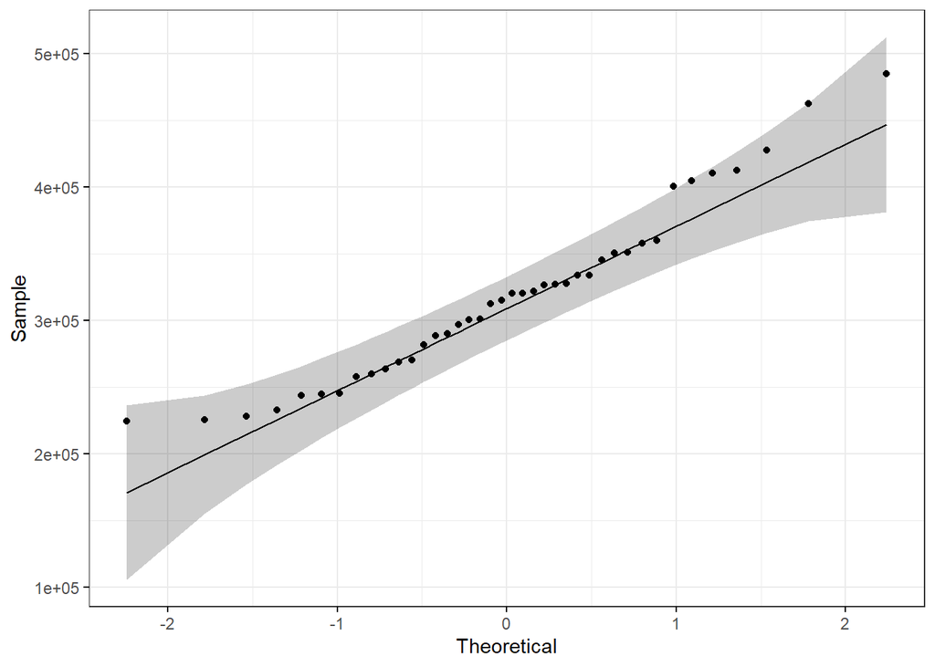

```r
# QQplots: Investigate heteroskedasticity visually

  # All datapoints combined
   genecopy.work %>%
    ggqqplot("qty_ng", ggtheme = theme_bw())
```

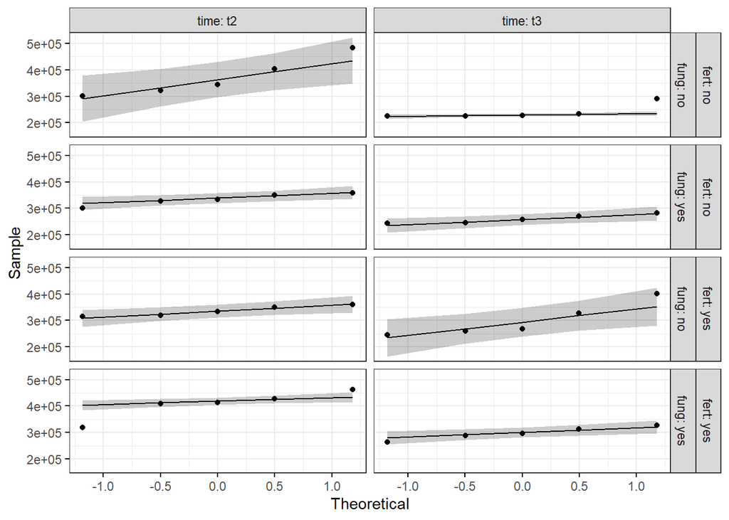

```r
  # Grouped by treatments and timepoints
   genecopy.work %>%
    ggqqplot("qty_ng", ggtheme = theme_bw())+
    facet_grid(fert + fung ~ time, labeller = "label_both")
```

```r
# The deviation in [fert:no|fung:no|time:t3] is clearly visible, exclude the outlier [id: 355]
  # [fert:yes|fung:yes|time:t2] shows also an outlier far away from the line, somewhere at 3e+05 [id:253]
  # Repeat normality test with filter of outliers
  # Heteroskedascticity not perfect but OK
```

Except for one group, all respective p-values above 0.05. The treatment group with a p-value under 0.05 had an outlier (see outlier check).

QQplots look fine.

Let’s redo the normality (shapiro) test without the outlier in the group which failed the normality test.

```r
# Shapiro Test with outliers removed
  genecopy.work %>%
    filter(id != "355")%>%
    #filter(id != "253")%>%
    group_by(fert, fung, time) %>%
    shapiro_test(qty_ng)
```

| fert | fung | time | variable | statistic | p |
| --- | --- | --- | --- | --- | --- |
| no | no | t2 | qty_ng | 0.9179646 | 0.5168951 |
| no | no | t3 | qty_ng | 0.8962706 | 0.4127717 |
| no | yes | t2 | qty_ng | 0.9477842 | 0.7213527 |
| no | yes | t3 | qty_ng | 0.9093859 | 0.4639090 |
| yes | no | t2 | qty_ng | 0.9352677 | 0.6327042 |
| yes | no | t3 | qty_ng | 0.8689447 | 0.2621768 |
| yes | yes | t2 | qty_ng | 0.8796757 | 0.3078440 |
| yes | yes | t3 | qty_ng | 0.9869404 | 0.9679214 |

```r
  # Now all trt grps pass the shapiro test (p > 0.05), normality can be assumed
  # QQplots look better, better heteroskedasticity
  # Let's provide a copydataset with the outliers excluded

   genecopy.work.filtered <- genecopy.work %>%
    #filter(id != "253")%>%
     filter(id != "355")


# Finished the preliminaries for the anova test
```

Lets move on to the ANOVA test for rhizo.

### ANOVA: choosing a model

An analysis of the dataset structure is needed to find the right statistical model. The data was generated in a randomized complete block design (RCBD).

##### Model parameters

###### Fixed effects

- Fertilizer (fert) (Binary variable (yes/no))
- Fungicide and growth (fung) (Binary variable (yes/no))

###### Random effects

- Time
- Block
- (Row)
- (Could possibly include rainfall 3-7 days before sampling)

#### Mixed effect model

The model needs to account for the above listed fixed and random effects. The regular lm() function of R stats package will fit all variables as fixed effects if they are integrated into the forumlae. Therefore we need the package nlme which can account for random effects. Because we are using only two timepoints I will stick to a linear model. Generally, I’d consider a non-linear model if all timepoints would be in the analysis. We are investigating gene copy numbers which are directly correlated and have a causal relation ship with number of bacteria. Bacteria growth is better estimated with a logistic regression.

I’ll do a stepwise modelling approach without the mathematic forumlae (will be done in the thesis tho).

##### All main effects + Interaction (Full model)

```r
# Fitting a linear mixed effect model to our genecopynumber dataset
  # Treatment variables (fert|fung) are treated as fixed effects
  # Time and Block are random effect variables (can't be replicated)
  # We use the package nlme to effectively input random effect variables for our model
  # Interaction of fert*fung must be tested, because we have two factorial experiment
  # It is also possible to just type in fert*fung as predictor variable, the package will fit also the main effects
  # If more timepoints of this are used, a non-linear model would be better because bacteria growth is not linear

  fit.all <- lme(qty_ng ~ fert+fung+fert*fung,
                  random = list(~1|block, ~1|time, ~1|row),
                  data=genecopy.work.filtered)
  summary(fit.all)
```

```
## Linear mixed-effects model fit by REML
##   Data: genecopy.work.filtered
##        AIC      BIC    logLik
##   891.8874 904.3302 -437.9437
##
## Random effects:
##  Formula: ~1 | block
##         (Intercept)
## StdDev:     2.11687
##
##  Formula: ~1 | time %in% block
##         (Intercept)
## StdDev:    44341.31
##
##  Formula: ~1 | row %in% time %in% block
##         (Intercept) Residual
## StdDev:    23.07462 47814.73
##
## Fixed effects:  qty_ng ~ fert + fung + fert * fung
##                     Value Std.Error DF   t-value p-value
## (Intercept)     303825.58  21371.60 17 14.216324  0.0000
## fertyes          14108.35  22107.80 17  0.638162  0.5319
## fungyes          -7086.54  22107.80 17 -0.320545  0.7525
## fertyes:fungyes  41075.50  30757.19 17  1.335476  0.1993
##  Correlation:
##                 (Intr) fertys fungys
## fertyes         -0.551
## fungyes         -0.551  0.532
## fertyes:fungyes  0.396 -0.719 -0.719
##
## Standardized Within-Group Residuals:
##        Min         Q1        Med         Q3        Max
## -1.3954961 -0.5807666 -0.1468039  0.3914567  2.5478950
##
## Number of Observations: 39
## Number of Groups:
##                    block          time %in% block row %in% time %in% block
##                        5                       10                       19
```

The interaction term is not significant, so I’m droping it from the model, leaving only the main effects in.

##### Both main effects (Reduced model)

```r
  fit.nointeraction <- lme(qty_ng ~ fert+fung,
                  random = list(~1|block, ~1|time),
                  data=genecopy.work.filtered)
  summary(fit.nointeraction)
```

```
## Linear mixed-effects model fit by REML
##   Data: genecopy.work.filtered
##        AIC      BIC    logLik
##   912.1677 921.6688 -450.0838
##
## Random effects:
##  Formula: ~1 | block
##         (Intercept)
## StdDev:    5.363311
##
##  Formula: ~1 | time %in% block
##         (Intercept) Residual
## StdDev:    44539.61 48404.24
##
## Fixed effects:  qty_ng ~ fert + fung
##                 Value Std.Error DF   t-value p-value
## (Intercept) 292542.79  19789.96 27 14.782382  0.0000
## fertyes      35322.05  15559.36 27  2.270148  0.0314
## fungyes      14127.16  15559.36 27  0.907953  0.3719
##  Correlation:
##         (Intr) fertys
## fertyes -0.418
## fungyes -0.418  0.032
##
## Standardized Within-Group Residuals:
##        Min         Q1        Med         Q3        Max
## -1.3802533 -0.4939084 -0.1678409  0.2697620  2.7488597
##
## Number of Observations: 39
## Number of Groups:
##           block time %in% block
##               5              10
```

Fertilizer (fert) is sig. but fungicide and growth regulators (fung) not. I’m dropping fung as a effect from the model.

##### Only Fert as main effect

```r
  fit.nofung <- lme(qty_ng ~ fert,
                  random = list(~1|block,~1|time),
                  data=genecopy.work.filtered)
  summary(fit.nofung)
```

```
## Linear mixed-effects model fit by REML
##   Data: genecopy.work.filtered
##        AIC      BIC    logLik
##   932.1343 940.1888 -461.0671
##
## Random effects:
##  Formula: ~1 | block
##         (Intercept)
## StdDev:    5.905738
##
##  Formula: ~1 | time %in% block
##         (Intercept) Residual
## StdDev:    44307.45 48320.63
##
## Fixed effects:  qty_ng ~ fert
##                 Value Std.Error DF   t-value p-value
## (Intercept) 300064.66  17904.63 28 16.759051  0.0000
## fertyes      34863.75  15524.34 28  2.245748  0.0328
##  Correlation:
##         (Intr)
## fertyes -0.447
##
## Standardized Within-Group Residuals:
##         Min          Q1         Med          Q3         Max
## -1.52321817 -0.63607437 -0.04244137  0.36656202  2.60355504
##
## Number of Observations: 39
## Number of Groups:
##           block time %in% block
##               5              10
```

This is the final model. We have a significant effect of fert on 16S gene copy numbers in the rhizo type soil samples.

## Soil

### Checking the datas balance

| fert | fung | time | variable | n | mean | sd |
| --- | --- | --- | --- | --- | --- | --- |
| no | no | t2 | qty_ng | 5 | 165023.1 | 225148.26 |
| no | no | t3 | qty_ng | 5 | 173726.1 | 98245.76 |
| no | yes | t2 | qty_ng | 5 | 488697.7 | 356575.50 |
| no | yes | t3 | qty_ng | 5 | 197417.0 | 18487.52 |
| yes | no | t2 | qty_ng | 5 | 425696.5 | 16304.07 |
| yes | no | t3 | qty_ng | 5 | 177265.7 | 26062.87 |
| yes | yes | t2 | qty_ng | 5 | 418115.6 | 33255.51 |
| yes | yes | t3 | qty_ng | 5 | 170149.4 | 58193.66 |

We have a balanced dataset (n is the same for each group). Moving on to a boxplot to visually inspect groups and look for outliers.

### Boxplot to inspect data visually

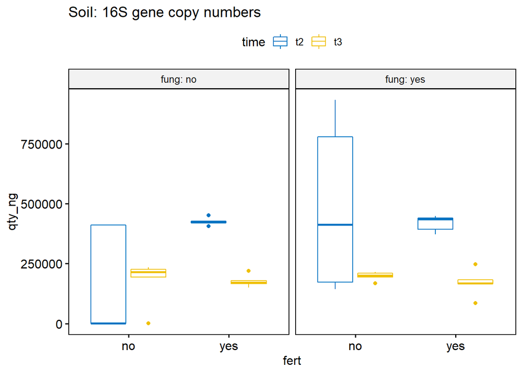

### Identifying the outliers.

```r
  outlier <-  genecopy.work %>%
    group_by(fert,fung, time) %>%
    identify_outliers(qty_ng)
  outlier
```

| fert | fung | time | id | qty_ng | block | row | subject | is.outlier | is.extreme |
| --- | --- | --- | --- | --- | --- | --- | --- | --- | --- |
| no | no | t3 | 382 | 99.02057 | f | 4 | 5 | TRUE | TRUE |
| no | yes | t3 | 359 | 167569.09678 | e | 3 | 14 | TRUE | FALSE |
| yes | no | t2 | 237 | 451179.80468 | c | 2 | 7 | TRUE | TRUE |
| yes | no | t2 | 251 | 406455.69955 | f | 3 | 9 | TRUE | FALSE |
| yes | no | t3 | 343 | 219416.83916 | d | 3 | 8 | TRUE | FALSE |
| yes | yes | t3 | 365 | 248031.82250 | e | 4 | 19 | TRUE | TRUE |
| yes | yes | t3 | 372 | 84677.62819 | f | 4 | 20 | TRUE | TRUE |

4/7 outliers are extreme:

> Values above Q3 + 1.5xIQR or below Q1 - 1.5xIQR are considered as outliers. Values above Q3 + 3xIQR or below Q1 - 3xIQR are considered as extreme points (or extreme outliers).

We have to check normality test and inspect QQplots to determine if ANOVA will be a viable option for eval here.

### Normality and heteroskedasticity

| fert | fung | time | variable | statistic | p |
| --- | --- | --- | --- | --- | --- |
| no | no | t2 | qty_ng | 0.6851687 | 0.006656990 |
| no | no | t3 | qty_ng | 0.6919417 | 0.007872342 |
| no | yes | t2 | qty_ng | 0.8895142 | 0.354666121 |
| no | yes | t3 | qty_ng | 0.8979027 | 0.398402760 |
| yes | no | t2 | qty_ng | 0.9328937 | 0.616232103 |
| yes | no | t3 | qty_ng | 0.9144834 | 0.494995499 |
| yes | yes | t2 | qty_ng | 0.8678699 | 0.257905362 |
| yes | yes | t3 | qty_ng | 0.9339753 | 0.623718305 |

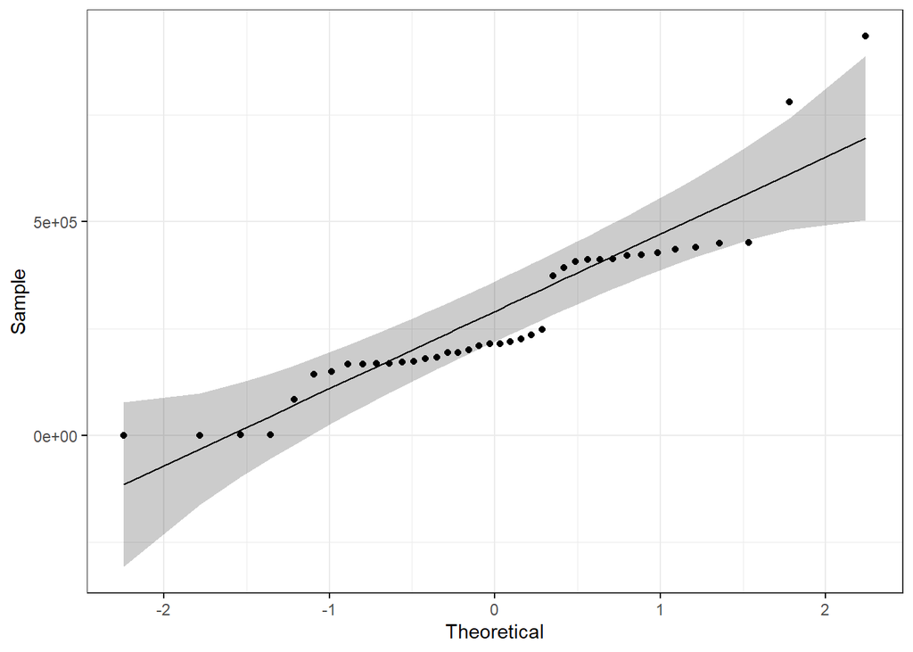

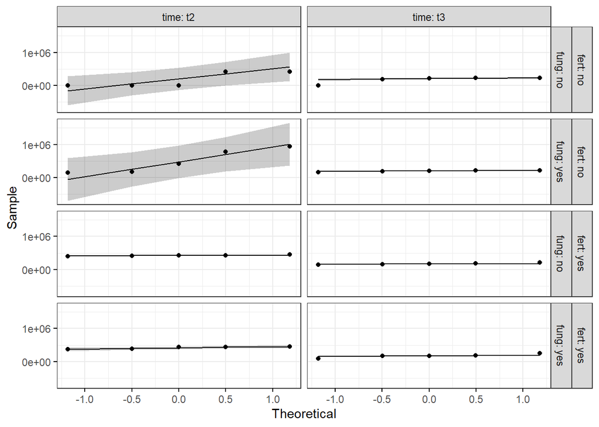

Two groups fail the normality test: [fert:no|fung:no|time:t2] and [fert:no|fung:no|time:t3]. Crosschecking the outlier output. In group [fert:no|fung:no|time:t3] we can exclude 382 which is an extreme outlier. But for the [fert:no|fung:no|time:t2] group, there is no outlier. The QQ plot give the same information as the outlier check. We have tails at the beginning and end which indicate extreme values. For QQPlots of the individual groups it looks fine.

##### Groups that failed the Shapiro Test and their replicates

###### Datatable from group [fert:no|fung:no|time:t2]

| id | qty_ng | fert | fung | block | row | time | subject |
| --- | --- | --- | --- | --- | --- | --- | --- |
| 198 | 411193.0973 | no | no | b | 1 | t2 | 1 |
| 201 | 418.7903 | no | no | c | 1 | t2 | 2 |
| 232 | 624.7354 | no | no | d | 2 | t2 | 3 |
| 259 | 412127.5257 | no | no | e | 3 | t2 | 4 |
| 286 | 751.1271 | no | no | f | 4 | t2 | 5 |

###### Datatable from group [fert:no|fung:no|time:t3]

| id | qty_ng | fert | fung | block | row | time | subject |
| --- | --- | --- | --- | --- | --- | --- | --- |
| 294 | 226141.20276 | no | no | b | 1 | t3 | 1 |
| 297 | 193850.79154 | no | no | c | 1 | t3 | 2 |
| 328 | 234292.21689 | no | no | d | 2 | t3 | 3 |
| 355 | 214247.11881 | no | no | e | 3 | t3 | 4 |
| 382 | 99.02057 | no | no | f | 4 | t3 | 5 |

##### Possible reasons why the gene copy numbers differ so much

For [fert:no|fung:no|time:t2] 198 and 259 have very high 16S gene copy numbers compared to the rest of the group. I have checked the raw values from the qPCR machine and they are correct. There are a few possibilities why the values are so high:

- The wells in the qPCR plate of 198 are close the standard, might be cross contaminated with standard (although the other replicates had the same proximity to the standard wells)
- The DNA extract was cross-contaminated with another DNA extract with higher gene copy numbers
- High heterogeneity of bacteria numbers in soil
- Sampled from a larger rhizodeposition where bacteria thrive

For ‘[fert:no|fung:no|time:t3]’ it is possibly enough to exclude 382 from the outlier list. For the repeated test 198, 259 and 382 are excluded.

| fert | fung | time | variable | statistic | p |
| --- | --- | --- | --- | --- | --- |
| no | no | t2 | qty_ng | 0.9812578 | 0.7377123 |
| no | no | t3 | qty_ng | 0.9572536 | 0.7616253 |
| no | yes | t2 | qty_ng | 0.8895142 | 0.3546661 |
| no | yes | t3 | qty_ng | 0.8979027 | 0.3984028 |
| yes | no | t2 | qty_ng | 0.9328937 | 0.6162321 |
| yes | no | t3 | qty_ng | 0.9144834 | 0.4949955 |
| yes | yes | t2 | qty_ng | 0.8678699 | 0.2579054 |
| yes | yes | t3 | qty_ng | 0.9339753 | 0.6237183 |

### Choosing a stastical model and performing ANOVA

An analysis of the dataset structure is needed to find the right statistical model. The data was generated in a randomized complete block design (RCBD).

##### Model parameters

###### Fixed effects

- Fertilizer (fert) (Binary variable (yes/no))
- Fungicide and growth (fung) (Binary variable (yes/no))

###### Random effects

- Time
- Block
- (Row)
- (Could possibly include rainfall 3-7 days before sampling)

#### Mixed effect model

The model needs to account for the above listed fixed and random effects. The regular lm() function of R stats package will fit all variables as fixed effects if they are integrated into the forumlae. Therefore we need the package nlme which can account for random effects. Because we are using only two timepoints I will stick to a linear model. Generally, I’d consider a non-linear model if all timepoints would be in the analysis. We are investigating gene copy numbers which are directly correlated and have a causal relation ship with number of bacteria. Bacteria growth is better estimated with a logistic regression.

I’ll do a stepwise modelling approach without the mathematic forumlae (will be done in the thesis tho).

##### All main effects + Interaction (Full model)

```
## Linear mixed-effects model fit by REML
##   Data: genecopy.work.filtered
##       AIC      BIC    logLik
##   836.957 848.1666 -410.4785
##
## Random effects:
##  Formula: ~1 | block
##         (Intercept)
## StdDev:    30.62974
##
##  Formula: ~1 | time %in% block
##         (Intercept)
## StdDev:    37576.01
##
##  Formula: ~1 | row %in% time %in% block
##         (Intercept) Residual
## StdDev:    121044.1 147502.9
##
## Fixed effects:  qty_ng ~ fert + fung + fert * fung
##                     Value Std.Error DF   t-value p-value
## (Intercept)      174709.5  70450.41 14  2.479894  0.0265
## fertyes          116325.3  86854.93 14  1.339305  0.2018
## fungyes          153301.8  83429.38 14  1.837504  0.0874
## fertyes:fungyes -125423.3 110614.30 14 -1.133880  0.2759
##  Correlation:
##                 (Intr) fertys fungys
## fertyes         -0.705
## fungyes         -0.714  0.641
## fertyes:fungyes  0.527 -0.746 -0.734
##
## Standardized Within-Group Residuals:
##        Min         Q1        Med         Q3        Max
## -1.3618387 -0.5626442 -0.1996662  0.4797629  2.3432915
##
## Number of Observations: 34
## Number of Groups:
##                    block          time %in% block row %in% time %in% block
##                        5                       10                       17
```

##### Reduced model (both main effects)

```
## Linear mixed-effects model fit by REML
##   Data: genecopy.work.filtered
##      AIC      BIC   logLik
##   860.97 869.5739 -424.485
##
## Random effects:
##  Formula: ~1 | block
##         (Intercept)
## StdDev:    21.16666
##
##  Formula: ~1 | time %in% block
##         (Intercept) Residual
## StdDev:    65455.94   178957
##
## Fixed effects:  qty_ng ~ fert + fung
##                 Value Std.Error DF   t-value p-value
## (Intercept) 186043.92  60829.47 22 3.0584503  0.0058
## fertyes      58646.49  62216.01 22 0.9426269  0.3561
## fungyes     121378.62  62297.52 22 1.9483700  0.0642
##  Correlation:
##         (Intr) fertys
## fertyes -0.579
## fungyes -0.607  0.125
##
## Standardized Within-Group Residuals:
##        Min         Q1        Med         Q3        Max
## -1.2575833 -0.6203814 -0.2079221  0.4018496  3.0342711
##
## Number of Observations: 34
## Number of Groups:
##           block time %in% block
##               5              10
```

##### Reduced model 2 (only fung)

```
## Linear mixed-effects model fit by REML
##   Data: genecopy.work.filtered
##        AIC      BIC    logLik
##   883.7451 891.0738 -436.8726
##
## Random effects:
##  Formula: ~1 | block
##         (Intercept)
## StdDev:    23.87227
##
##  Formula: ~1 | time %in% block
##         (Intercept) Residual
## StdDev:    74228.73 176172.7
##
## Fixed effects:  qty_ng ~ fung
##                Value Std.Error DF  t-value p-value
## (Intercept) 220215.5  50243.92 23 4.382929  0.0002
## fungyes     112582.4  60916.43 23 1.848145  0.0775
##  Correlation:
##         (Intr)
## fungyes -0.644
##
## Standardized Within-Group Residuals:
##         Min          Q1         Med          Q3         Max
## -1.51351777 -0.63663387 -0.05071989  0.47593626  2.81534956
##
## Number of Observations: 34
## Number of Groups:
##           block time %in% block
##               5              10
```

Fungicide + Growth thingy is borderline significant. May be worth to do post-hoc tests

# Climate data

Close to experimental Site (53°21’58.5“N|13°48’13.3”E). Data extracted from wetterkontor.com from weather station in Grünow (53°19’01.7“N|13°56’55.0”E)

```r
#Read data as tibble (tidyverse)
  climate <-
    read_delim("C:/Users/jjohn/OneDrive/MScthesis/data/clim.csv",";",) %>%
    filter (date != 0) #deletes empty days (artifact from data mining)
  climate$date <- as.Date(climate$date,"%d.%m.%Y") #formats the date correct

#Summary statistics as we have day data, condense to month
  summary <- climate %>%
    mutate(month = format(date,"%m"), year = format (date, "%y"))%>% #new month and year var
    group_by(id, month, year)%>%                                    #group by new vars
    summarise(
      avg = mean(value) #mean it
    )
```

[figure not shown]

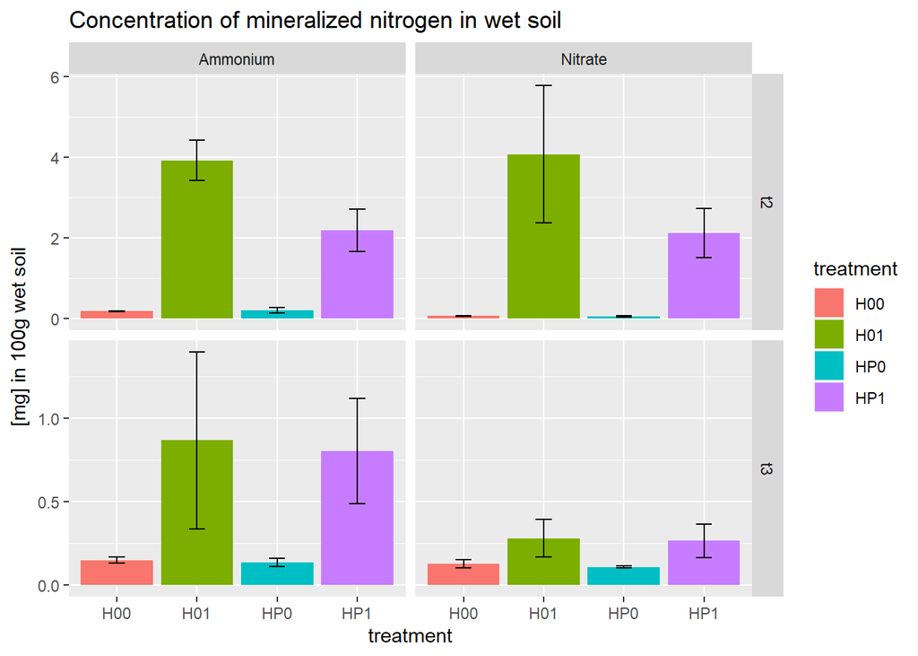

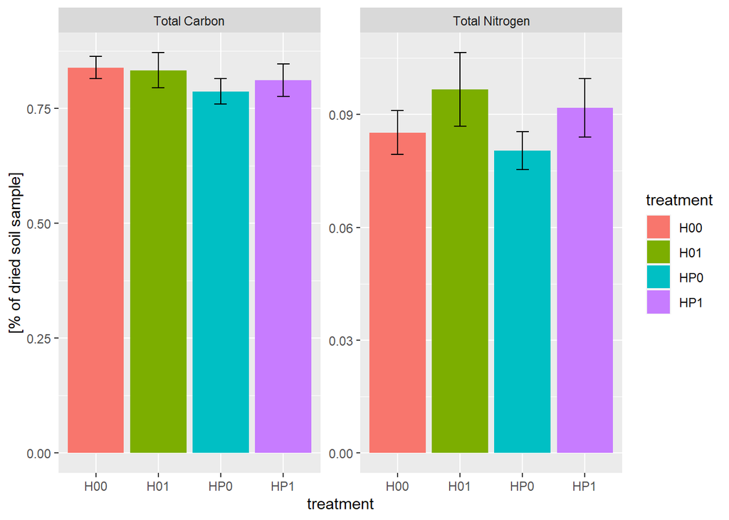

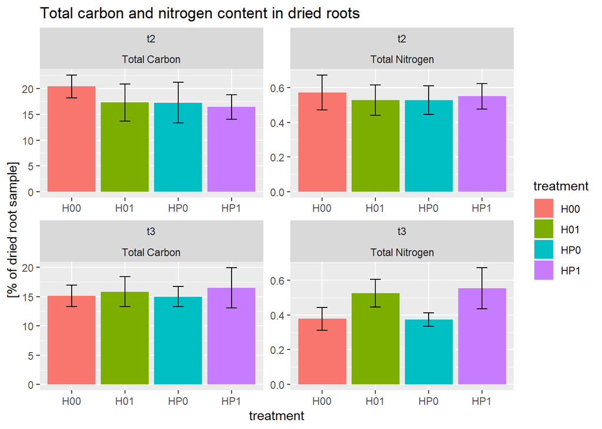

[figure not shown]

```r
# Plotting the weather data

  summary$id <-
    as.factor(summary$id)
  summary$time <-
    lubridate::ymd(paste0(summary$year,summary$month,"01"))#reintroducing date format for ggplot2

# consistent coloring scheme
  my_color <- c ("deepskyblue1", "goldenrod1", "black", "red", "dodgerblue4")
  names(my_color) <- levels(summary$id)
  my_scale <- scale_color_manual(name = "Legend",
                                 values = my_color,
                                 breaks=c("temp_max","temp_avg", "temp_min"),
                                 labels=c("Maximum", "Average", "Minimum"))

# filtering data for separate plots

  temp <- filter(summary, id =="temp_max" |id =="temp_min" | id=="temp_avg")
  sun <- filter(summary,id =="sunshine")
  rain<- filter(summary,id=="rainfall")


# ggplot area
  #temperature
  temp$title <- "Temperature"
  a <- ggplot(temp, aes(time,avg,color=id)) +
    geom_line() +
    ylab("°C")+
    xlab("2019-2020")+
    facet_grid(~title)+
    NULL
  plot_temp <- a + my_scale

  #rainfall, sunshine
  rain$title <- "Rainfall"
  b <- ggplot(rain, aes(time,avg, color=id)) +
    geom_line() +
    ylab(expression(paste("L/m"^"2")))+
    xlab("2019-2020")+
    facet_grid(~title)+
    NULL
  plot_rain <- b + my_scale

  sun$title <- "Sunshine"
  c <- ggplot(sun, aes(time,avg,color=id)) +
    geom_line() +
    ylab("Hours")+
    xlab("2019-2020")+
    facet_grid(~title)+
    NULL
  plot_sun <- c + my_scale


#cowplot to arrange
  #Plotting two plots together
  plot_other<- plot_grid(plot_rain + theme(legend.position="none"),
                         plot_sun + theme(legend.position="none")
                         ,labels = c('B', 'C'))
  # so they can be in one row
  prow <- plot_grid(plot_temp,
            plot_other,
            labels = c('A', ''),
            ncol = 1, nrow = 2)
  prow
```